# DRD_2026_Lesson_4

```r
rm(list=ls())
setwd("~/Dropbox/DRD_2026/4")
suppressMessages(library(minfi))
```

# CHUNK 1: Beta and M values

We load the MSet object, which contains the methylation and unmethylation signals

```r
load("~/Dropbox/DRD_2026/3/MSet_raw.RData")
ls()
```

```
## [1] "MSet.raw"
```

```r
MSet.raw
```

```
## class: MethylSet
## dim: 485512 8
## metadata(0):
## assays(2): Meth Unmeth
## rownames(485512): cg00050873 cg00212031 ... ch.22.47579720R
##   ch.22.48274842R
## rowData names(0):
## colnames(8): 9344737127_R01C02 9344737127_R03C02 ... 9376538140_R01C01
##   9376538140_R04C01
## colData names(9): Sample_ID Sample_Well ... Basename filenames
## Annotation
##   array: IlluminaHumanMethylation450k
##   annotation: ilmn12.hg19
## Preprocessing
##   Method: Raw (no normalization or bg correction)
##   minfi version: 1.56.0
##   Manifest version: 0.4.0
```

Remember that it is a MethylSet class object. If we want to know the accessor functions for this class of objects, we can go to the help page:

```r
?MethylSet
```

The functions getBeta and getM allow to retrieve beta and M values matrices:

```r
beta <- getBeta(MSet.raw)
class(beta)
```

```
## [1] "matrix" "array"
```

```r
dim(beta)
```

```
## [1] 485512      8
```

```r
head(beta)
```

```
##            9344737127_R01C02 9344737127_R03C02 9344737127_R06C01
## cg00050873         0.5007407         0.5135834         0.5134752
## cg00212031         0.5153473         0.4880137         0.4010601
## cg00213748         0.4892308         0.5732689         0.4657763
## cg00214611         0.5833333         0.5009074         0.4842767
## cg00455876         0.4772727         0.3244963         0.4394099
## cg01707559         0.5583414         0.4735062         0.3702253
##            9344737127_R02C02 9376538140_R02C01 9376538140_R05C01
## cg00050873         0.5063452         0.5548961         0.4721254
## cg00212031         0.4948805         0.4677914         0.5000000
## cg00213748         0.4533333         0.4276316         0.5217391
## cg00214611         0.5707237         0.4968454         0.5383178
## cg00455876         0.4109589         0.4433121         0.4494519
## cg01707559         0.5269017         0.5052894         0.4174528
##            9376538140_R01C01 9376538140_R04C01
## cg00050873         0.5183752        0.90447562
## cg00212031         0.4780316        0.06670492
## cg00213748         0.5118483        0.79562738
## cg00214611         0.6069767        0.03851709
## cg00455876         0.2972973        0.76427105
## cg01707559         0.4085422        0.06711106
```

```r
summary(beta)
```

```
##  9344737127_R01C02 9344737127_R03C02 9344737127_R06C01 9344737127_R02C02
##  Min.   :0.0000    Min.   :0.0000    Min.   :0.0000    Min.   :0.0000
##  1st Qu.:0.1234    1st Qu.:0.1003    1st Qu.:0.1028    1st Qu.:0.1052
##  Median :0.5496    Median :0.5916    Median :0.6426    Median :0.5848
##  Mean   :0.4879    Mean   :0.4952    Mean   :0.5116    Mean   :0.4928
##  3rd Qu.:0.7949    3rd Qu.:0.8178    3rd Qu.:0.8408    3rd Qu.:0.8082
##  Max.   :1.0000    Max.   :1.0000    Max.   :1.0000    Max.   :1.0000
##  NA's   :13        NA's   :18        NA's   :14        NA's   :14
##  9376538140_R02C01 9376538140_R05C01 9376538140_R01C01  9376538140_R04C01
##  Min.   :0.01148   Min.   :0.0000    Min.   :0.009437   Min.   :0.00000
##  1st Qu.:0.10393   1st Qu.:0.1254    1st Qu.:0.093736   1st Qu.:0.09656
##  Median :0.49236   Median :0.5564    Median :0.572396   Median :0.61699
##  Mean   :0.47257   Mean   :0.4954    Mean   :0.485536   Mean   :0.49915
##  3rd Qu.:0.81101   3rd Qu.:0.8127    3rd Qu.:0.807981   3rd Qu.:0.82909
##  Max.   :0.98989   Max.   :0.9915    Max.   :1.000000   Max.   :0.99289
##  NA's   :1         NA's   :2         NA's   :3          NA's   :3
```

In our dataset, minimum for beta values is 0, maximum is 1. We have also some NAs: these are the positions for which both the Methylation and Unmethylation values in the MSet.raw are equal to 0 (by default, in minfi the offset is set to 0)

```r
M <- getM(MSet.raw)
dim(M)
```

```
## [1] 485512      8
```

```r
head(M)
```

```
##            9344737127_R01C02 9344737127_R03C02 9344737127_R06C01
## cg00050873       0.004274655       0.078406345        0.07778112
## cg00212031       0.088593923      -0.069183565       -0.57859298
## cg00213748      -0.062156476       0.425884882       -0.19780678
## cg00214611       0.485426827       0.005236648       -0.09076546
## cg00455876      -0.131244533      -1.057761720       -0.35137886
## cg01707559       0.338215750      -0.153033222       -0.76643250
##            9344737127_R02C02 9376538140_R02C01 9376538140_R05C01
## cg00050873        0.03661859        0.31807577        -0.1610249
## cg00212031       -0.02954428       -0.18612642         0.0000000
## cg00213748       -0.27008916       -0.42057568         0.1255309
## cg00214611        0.41088586       -0.01820460         0.2215578
## cg00455876       -0.51937416       -0.32854597        -0.2927020
## cg01707559        0.15539368        0.03052487        -0.4807617
##            9376538140_R01C01 9376538140_R04C01
## cg00050873        0.10608726          3.243141
## cg00212031       -0.12685628         -3.806468
## cg00213748        0.06838697          1.960891
## cg00214611        0.62702656         -4.641691
## cg00455876       -1.24100810          1.696955
## cg01707559       -0.53378985         -3.797083
```

```r
summary(M)
```

```
##  9344737127_R01C02 9344737127_R03C02 9344737127_R06C01 9344737127_R02C02
##  Min.   :   -Inf   Min.   :   -Inf   Min.   :   -Inf   Min.   :  -Inf
##  1st Qu.:-2.8282   1st Qu.:-3.1659   1st Qu.:-3.1261   1st Qu.:-3.088
##  Median : 0.2873   Median : 0.5349   Median : 0.8462   Median : 0.494
##  Mean   :    NaN   Mean   :    NaN   Mean   :    NaN   Mean   :   NaN
##  3rd Qu.: 1.9545   3rd Qu.: 2.1662   3rd Qu.: 2.4012   3rd Qu.: 2.075
##  Max.   :    Inf   Max.   :    Inf   Max.   :    Inf   Max.   :   Inf
##  NA's   :13        NA's   :18        NA's   :14        NA's   :14
##  9376538140_R02C01 9376538140_R05C01 9376538140_R01C01 9376538140_R04C01
##  Min.   :-6.4279   Min.   :   -Inf   Min.   :-6.7137   Min.   :   -Inf
##  1st Qu.:-3.1080   1st Qu.:-2.8022   1st Qu.:-3.2733   1st Qu.:-3.2259
##  Median :-0.0441   Median : 0.3269   Median : 0.4207   Median : 0.6879
##  Mean   :-0.3761   Mean   :   -Inf   Mean   :    Inf   Mean   :   -Inf
##  3rd Qu.: 2.1014   3rd Qu.: 2.1171   3rd Qu.: 2.0731   3rd Qu.: 2.2783
##  Max.   : 6.6138   Max.   : 6.8600   Max.   :    Inf   Max.   : 7.1254
##  NA's   :1         NA's   :2         NA's   :3         NA's   :3
```

In our dataset, minimum for M values is -Inf (Methylation value=0, Unmethylation value>0), maximum is +Inf (Methylation value>0, Unmethylation value=0). We have also some NAs: these are the positions for which both the Methylation and Unmethylation values in the MSet.raw are equal to 0 (by default, in minfi the offset is set to 0)

Note! The output of getBeta and getM functions is a matrix. We can also convert the output of these functions to a dataframe (as we have done with the output of getRed and getGreen functions in the last lesson):

```r
beta_df <- data.frame(getBeta(MSet.raw))
class(beta_df)
```

```
## [1] "data.frame"
```

Do you note some differences between beta and beta_df?

```r
dim(beta)
```

```
## [1] 485512      8
```

```r
dim(beta_df)
```

```
## [1] 485512      8
```

```r
head(beta)
```

```
##            9344737127_R01C02 9344737127_R03C02 9344737127_R06C01
## cg00050873         0.5007407         0.5135834         0.5134752
## cg00212031         0.5153473         0.4880137         0.4010601
## cg00213748         0.4892308         0.5732689         0.4657763
## cg00214611         0.5833333         0.5009074         0.4842767
## cg00455876         0.4772727         0.3244963         0.4394099
## cg01707559         0.5583414         0.4735062         0.3702253
##            9344737127_R02C02 9376538140_R02C01 9376538140_R05C01
## cg00050873         0.5063452         0.5548961         0.4721254
## cg00212031         0.4948805         0.4677914         0.5000000
## cg00213748         0.4533333         0.4276316         0.5217391
## cg00214611         0.5707237         0.4968454         0.5383178
## cg00455876         0.4109589         0.4433121         0.4494519
## cg01707559         0.5269017         0.5052894         0.4174528
##            9376538140_R01C01 9376538140_R04C01
## cg00050873         0.5183752        0.90447562
## cg00212031         0.4780316        0.06670492
## cg00213748         0.5118483        0.79562738
## cg00214611         0.6069767        0.03851709
## cg00455876         0.2972973        0.76427105
## cg01707559         0.4085422        0.06711106
```

```r
head(beta_df)
```

```
##            X9344737127_R01C02 X9344737127_R03C02 X9344737127_R06C01
## cg00050873          0.5007407          0.5135834          0.5134752
## cg00212031          0.5153473          0.4880137          0.4010601
## cg00213748          0.4892308          0.5732689          0.4657763
## cg00214611          0.5833333          0.5009074          0.4842767
## cg00455876          0.4772727          0.3244963          0.4394099
## cg01707559          0.5583414          0.4735062          0.3702253
##            X9344737127_R02C02 X9376538140_R02C01 X9376538140_R05C01
## cg00050873          0.5063452          0.5548961          0.4721254
## cg00212031          0.4948805          0.4677914          0.5000000
## cg00213748          0.4533333          0.4276316          0.5217391
## cg00214611          0.5707237          0.4968454          0.5383178
## cg00455876          0.4109589          0.4433121          0.4494519
## cg01707559          0.5269017          0.5052894          0.4174528
##            X9376538140_R01C01 X9376538140_R04C01
## cg00050873          0.5183752         0.90447562
## cg00212031          0.4780316         0.06670492
## cg00213748          0.5118483         0.79562738
## cg00214611          0.6069767         0.03851709
## cg00455876          0.2972973         0.76427105
## cg01707559          0.4085422         0.06711106
```

Now we want to plot the density distribution of mean (across the 8 samples) beta and M values for each CpG

First of all, we have to calculate the mean of each row of the matrix across the 8 samples.

To calculate the mean, we will use the mean() function. As we know that in our input there are some missing values, we will specify that NA values should be stripped (see this page https://www.statmethods.net/input/missingdata.html) using the na.rm=T argument.

To calculate the mean of each row of the matrix, we will use the apply() function, which takes as input a dataframe or matrix and returns a vector (see here for example: http://petewerner.blogspot.it/2012/12/using-apply-sapply-lapply-in-r.html). Note that the “MARGIN” argument in the function allows to specify that the function mean() should be applied to each row (set “MARGIN” to 1) or to each column (set “MARGIN” to 2) of the matrix/dataframe.

```r
mean_of_beta <- apply(beta,1,mean,na.rm=T)
head(beta)
```

```
##            9344737127_R01C02 9344737127_R03C02 9344737127_R06C01
## cg00050873         0.5007407         0.5135834         0.5134752
## cg00212031         0.5153473         0.4880137         0.4010601
## cg00213748         0.4892308         0.5732689         0.4657763
## cg00214611         0.5833333         0.5009074         0.4842767
## cg00455876         0.4772727         0.3244963         0.4394099
## cg01707559         0.5583414         0.4735062         0.3702253
##            9344737127_R02C02 9376538140_R02C01 9376538140_R05C01
## cg00050873         0.5063452         0.5548961         0.4721254
## cg00212031         0.4948805         0.4677914         0.5000000
## cg00213748         0.4533333         0.4276316         0.5217391
## cg00214611         0.5707237         0.4968454         0.5383178
## cg00455876         0.4109589         0.4433121         0.4494519
## cg01707559         0.5269017         0.5052894         0.4174528
##            9376538140_R01C01 9376538140_R04C01
## cg00050873         0.5183752        0.90447562
## cg00212031         0.4780316        0.06670492
## cg00213748         0.5118483        0.79562738
## cg00214611         0.6069767        0.03851709
## cg00455876         0.2972973        0.76427105
## cg01707559         0.4085422        0.06711106
```

```r
head(mean_of_beta)
```

```
## cg00050873 cg00212031 cg00213748 cg00214611 cg00455876 cg01707559
##  0.5605021  0.4264787  0.5298070  0.4774873  0.4508088  0.4159213
```

```r
dim(beta)
```

```
## [1] 485512      8
```

```r
length(mean_of_beta)
```

```
## [1] 485512
```

Now we can calculate the density distribution

```r
?density
```

```
## Help on topic 'density' was found in the following packages:
##
##   Package               Library
##   stats                 /Library/Frameworks/R.framework/Versions/4.5-arm64/Resources/library
##   BiocGenerics          /Library/Frameworks/R.framework/Versions/4.5-arm64/Resources/library
##
##
## Using the first match ...
```

```r
d_mean_of_beta <- density(mean_of_beta)
d_mean_of_beta
```

```
##
## Call:
##  density.default(x = mean_of_beta)
##
## Data: mean_of_beta (485512 obs.);    Bandwidth 'bw' = 0.02181
##
##        x                  y
##  Min.   :-0.05329   Min.   :0.0004777
##  1st Qu.: 0.22380   1st Qu.:0.4386833
##  Median : 0.50089   Median :0.6414534
##  Mean   : 0.50089   Mean   :0.9004647
##  3rd Qu.: 0.77798   3rd Qu.:1.1724923
##  Max.   : 1.05507   Max.   :3.0967845
```

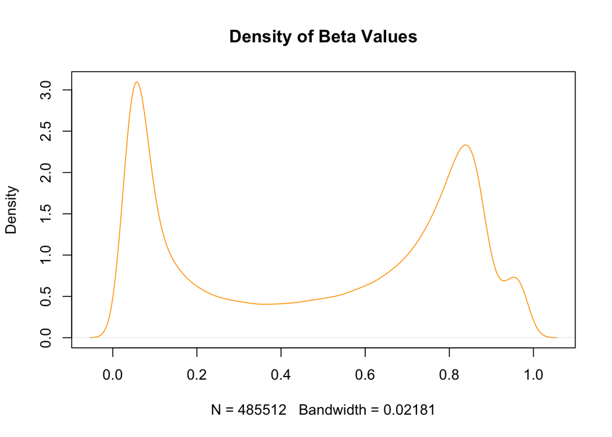

```r
plot(d_mean_of_beta,main="Density of Beta Values",col="orange")
```

We apply the same steps on M values:

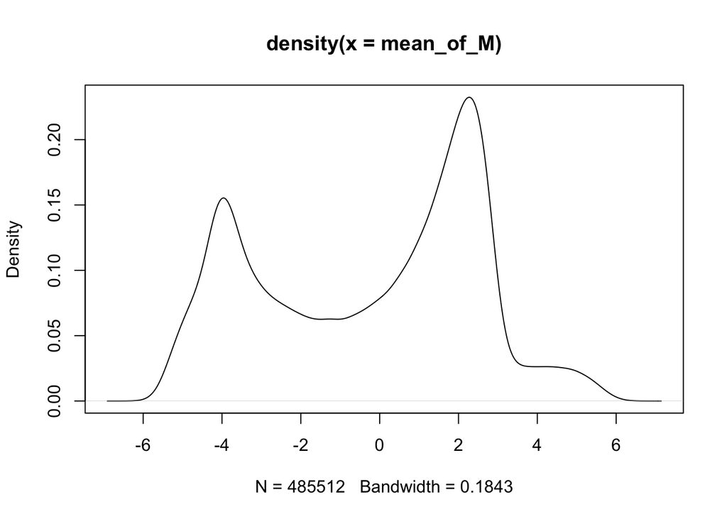

```r
mean_of_M <- apply(M,1,mean,na.rm=T)
d_mean_of_M <- density(mean_of_M)
plot(d_mean_of_M)
```

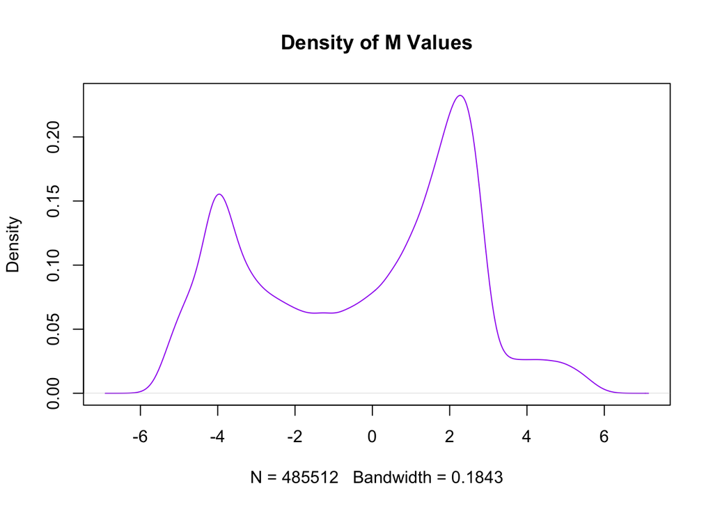

```r
plot(d_mean_of_M,main="Density of M Values",col="purple")
```

We can put several plots in the same panel by setting the option “mfrow” in the par() function (http://www.statmethods.net/advgraphs/layout.html). Yu can find a quick guide to plots here: http://www.statmethods.net/graphs/index.html

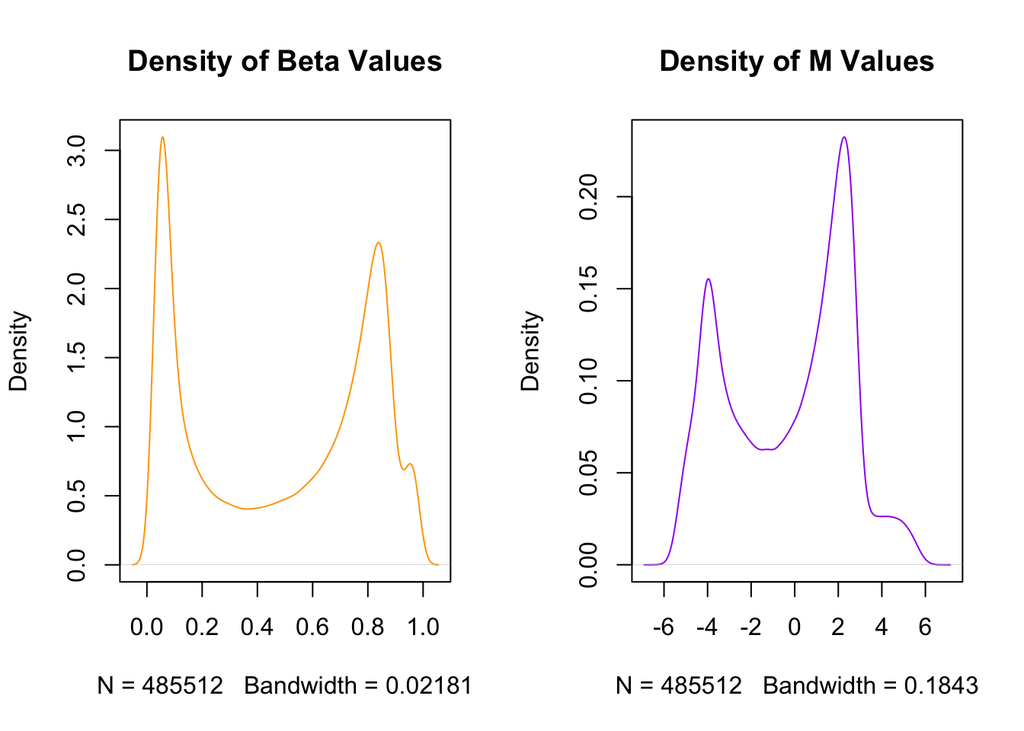

```r
par(mfrow=c(1,2))
plot(d_mean_of_beta,main="Density of Beta Values",col="orange")
plot(d_mean_of_M,main="Density of M Values",col="purple")
```

or

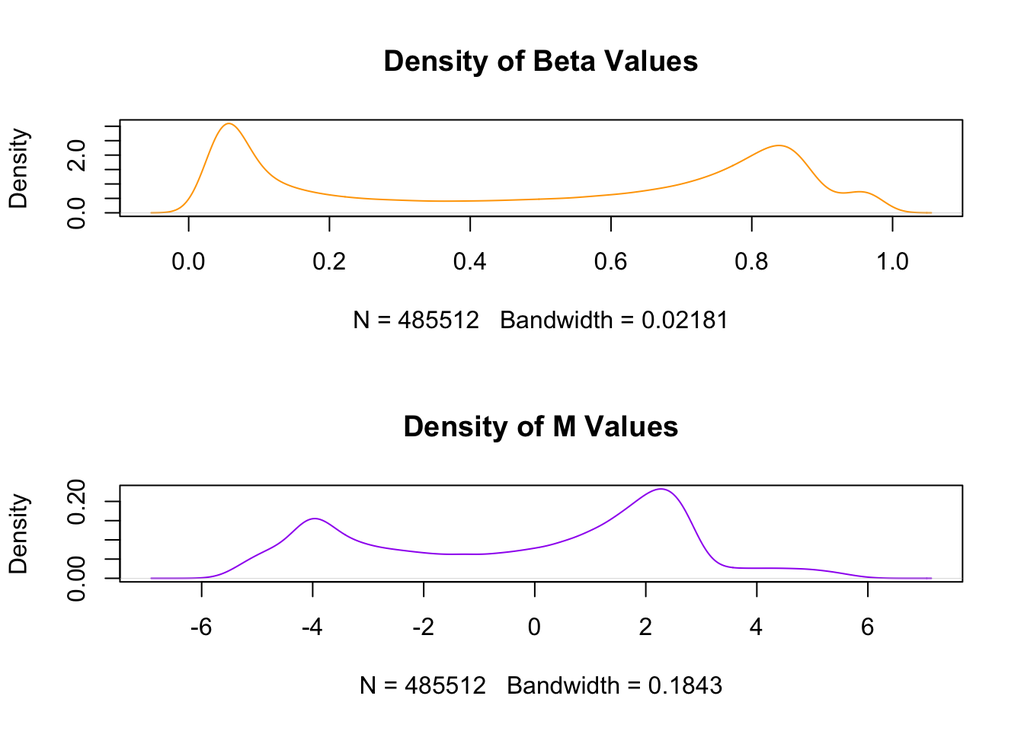

```r
par(mfrow=c(2,1))
plot(d_mean_of_beta,main="Density of Beta Values",col="orange")
plot(d_mean_of_M,main="Density of M Values",col="purple")
```

Another useful plot to represent our data is boxplots:

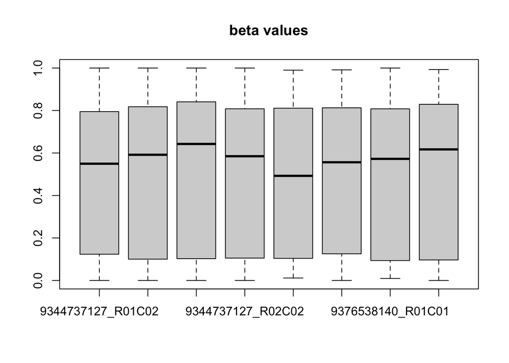

```r
boxplot(beta,main="beta values")
```

# CHUNK 2: Save plots

You can save the graph in a variety of formats from the menu File -> Save As. You can also save the graph via code using one of the following functions:

Function Output to

pdf(“mygraph.pdf”) pdf file

win.metafile(“mygraph.wmf”) windows metafile

png(“mygraph.png”) png file

jpeg(“mygraph.jpg”) jpeg file

bmp(“mygraph.bmp”) bmp file

postscript(“mygraph.ps”) postscript file

For example (the file will be saved in the working directory):

```r
pdf("Picture1.pdf",width=10,height=5)
par(mfrow=c(1,2))
plot(d_mean_of_beta,main="Density of Beta Values",col="blue")
boxplot(beta)
dev.off() #shuts down the graphical device
```

# CHUNK 3: plot the density distribution of beta values for Infinium I and II probes

We want to subset the dataframe of beta values according to Type I and II First of all, we need to know what are the Type I and Type II probes. To this aim, we need our manifest file.

```r
load('~/Dropbox/DRD_2026/2/Illumina450Manifest_clean.RData')
ls()
```

```
## [1] "beta"                      "beta_df"
## [3] "d_mean_of_beta"            "d_mean_of_M"
## [5] "Illumina450Manifest_clean" "M"
## [7] "mean_of_beta"              "mean_of_M"
## [9] "MSet.raw"
```

```r
str(Illumina450Manifest_clean)
```

```
## 'data.frame':    485512 obs. of  33 variables:
##  $ IlmnID                     : Factor w/ 485512 levels "cg00000029","cg00000108",..: 892 1231 1464 1502 2807 4566 4600 4616 4811 5219 ...
##  $ Name                       : Factor w/ 485512 levels "cg00000029","cg00000108",..: 892 1231 1464 1502 2807 4566 4600 4616 4811 5219 ...
##  $ AddressA_ID                : Factor w/ 485512 levels "10600322","10600328",..: 163924 171461 142476 49179 74479 146426 155259 448531 56092 200778 ...
##  $ AlleleA_ProbeSeq           : Factor w/ 485512 levels "AAAAAAAAAAAAAAAAAACCACAAAAAAATCCCCACTCTAAAACCCCACA",..: 35017 143540 35761 427267 41000 296053 482818 335327 460590 128010 ...
##  $ AddressB_ID                : Factor w/ 135477 levels "","10600313",..: 1 45514 1 1 1 60128 56499 76848 1 1 ...
##  $ AlleleB_ProbeSeq           : Factor w/ 135477 levels "","AAAAAAAAAAAAAAAAAACCGCGAAAAAATCCCCGCTCTAAAACCCCGCG",..: 1 49667 1 1 1 77344 135092 95678 1 1 ...
##  $ Infinium_Design_Type       : Factor w/ 2 levels "I","II": 2 1 2 2 2 1 1 1 2 2 ...
##  $ Next_Base                  : Factor w/ 4 levels "","A","C","T": 1 2 1 1 1 4 2 2 1 1 ...
##  $ Color_Channel              : Factor w/ 3 levels "","Grn","Red": 1 3 1 1 1 3 3 3 1 1 ...
##  $ Forward_Sequence           : Factor w/ 485512 levels "AAAAAAAAAAAAAAAAAAAAAAAAAAAAAAATATGTCTGCTAAATAATCACAGAGTGAAA[CG]AAGAGGAAGAAACTAAAGTACAGTTTGGAACATAGTACAGTGCCCCTGGGTACTGAATCA",..: 25105 392558 395302 218895 81395 152101 421754 296779 478968 55951 ...
##  $ Genome_Build               : int  37 37 37 37 37 37 37 37 37 37 ...
##  $ CHR                        : Factor w/ 24 levels "1","10","11",..: 24 24 24 24 24 24 24 24 24 24 ...
##  $ MAPINFO                    : int  8553009 9363356 25314171 22741795 21664296 21239348 8148233 15815688 4868996 6133740 ...
##  $ SourceSeq                  : Factor w/ 485343 levels "AAAAAAAAAACCAACCCCAAACAAAAACCCTGTGCCCAGAATTGCATTCG",..: 28961 285896 116667 116691 29627 123294 148856 152723 189022 323597 ...
```

[output cut: 19 more lines]

We subset the Illumina450Manifest_clean in two dataframes, containing only type I (dfI) or type II (dfII) probes

```r
dfI <- Illumina450Manifest_clean[Illumina450Manifest_clean$Infinium_Design_Type=="I",]
dfI <- droplevels(dfI)
dim(dfI)
```

```
## [1] 135476     33
```

```r
str(dfI)
```

```
## 'data.frame':    135476 obs. of  33 variables:
##  $ IlmnID                     : Factor w/ 135476 levels "cg00000622","cg00000769",..: 311 1089 1099 1106 2280 8496 10019 10061 10250 11112 ...
##  $ Name                       : Factor w/ 135476 levels "cg00000622","cg00000769",..: 311 1089 1099 1106 2280 8496 10019 10061 10250 11112 ...
##  $ AddressA_ID                : Factor w/ 135476 levels "10600328","10600369",..: 47762 40844 43302 125252 36295 74624 33361 35577 70485 133756 ...
##  $ AlleleA_ProbeSeq           : Factor w/ 135476 levels "AAAAAAAAAAAAAAAAAACCACAAAAAAATCCCCACTCTAAAACCCCACA",..: 46999 97650 135088 103784 39883 50177 55080 65466 80679 129398 ...
##  $ AddressB_ID                : Factor w/ 135476 levels "10600313","10600353",..: 45513 60127 56498 76847 124346 114306 100943 109732 132012 11815 ...
##  $ AlleleB_ProbeSeq           : Factor w/ 135476 levels "AAAAAAAAAAAAAAAAAACCGCGAAAAAATCCCCGCTCTAAAACCCCGCG",..: 49666 77343 135091 95677 35570 107971 45139 58259 69459 129398 ...
##  $ Infinium_Design_Type       : Factor w/ 1 level "I": 1 1 1 1 1 1 1 1 1 1 ...
##  $ Next_Base                  : Factor w/ 3 levels "A","C","T": 1 3 1 1 1 1 2 1 2 2 ...
##  $ Color_Channel              : Factor w/ 2 levels "Grn","Red": 2 2 2 2 2 2 1 2 1 1 ...
##  $ Forward_Sequence           : Factor w/ 135476 levels "AAAAAAAAAAAAAAAAAAAAAAAAAAAAGCTTGCCCCAACATCGGTATATTCCAAATTCG[CG]CGTGCTTCCGAAGGCTCATATTCTCGGCCCTTTCAGACGCTCTTAAAATTTTTCTCCTAG",..: 113476 36406 121253 84324 53100 15696 80195 14484 40097 106165 ...
##  $ Genome_Build               : int  37 37 37 37 37 37 37 37 37 37 ...
##  $ CHR                        : Factor w/ 24 levels "1","10","11",..: 24 24 24 24 24 24 24 24 24 24 ...
##  $ MAPINFO                    : int  9363356 21239348 8148233 15815688 9385539 6778695 15815552 9194502 22918038 22737591 ...
##  $ SourceSeq                  : Factor w/ 135431 levels "AAAAAAAAAATCCCCGTTGCTCTTTACACCCCGGAAACGGCAAGGGAACG",..: 83347 29309 36834 39256 98271 40812 71752 120603 16821 126495 ...
```

[output cut: 19 more lines]

```r
dfII <- Illumina450Manifest_clean[Illumina450Manifest_clean$Infinium_Design_Type=="II",]
dfII <- droplevels(dfII)
```

Remember that in the beta matrix, which contains the beta values, the names of the probes are stored in the rownames of the matrix:

```r
head(beta)
```

```
##            9344737127_R01C02 9344737127_R03C02 9344737127_R06C01
## cg00050873         0.5007407         0.5135834         0.5134752
## cg00212031         0.5153473         0.4880137         0.4010601
## cg00213748         0.4892308         0.5732689         0.4657763
## cg00214611         0.5833333         0.5009074         0.4842767
## cg00455876         0.4772727         0.3244963         0.4394099
## cg01707559         0.5583414         0.4735062         0.3702253
##            9344737127_R02C02 9376538140_R02C01 9376538140_R05C01
## cg00050873         0.5063452         0.5548961         0.4721254
## cg00212031         0.4948805         0.4677914         0.5000000
## cg00213748         0.4533333         0.4276316         0.5217391
## cg00214611         0.5707237         0.4968454         0.5383178
## cg00455876         0.4109589         0.4433121         0.4494519
## cg01707559         0.5269017         0.5052894         0.4174528
##            9376538140_R01C01 9376538140_R04C01
## cg00050873         0.5183752        0.90447562
## cg00212031         0.4780316        0.06670492
## cg00213748         0.5118483        0.79562738
## cg00214611         0.6069767        0.03851709
## cg00455876         0.2972973        0.76427105
## cg01707559         0.4085422        0.06711106
```

Now we subset the beta matrix in order to retain only the rows whose name is in the first column of dfI…

```r
beta_I <- beta[rownames(beta) %in% dfI$IlmnID,]
dim(beta_I)
```

```
## [1] 135476      8
```

… or in the first column of dfII

```r
beta_II <- beta[rownames(beta) %in% dfII$IlmnID,]
dim(beta_II)
```

```
## [1] 350036      8
```

For each probe in the mean_of_beta_I and mean_of_beta_II matrices, we calculate the mean of beta values across the 8 samples…

```r
mean_of_beta_I <- apply(beta_I,1,mean)
mean_of_beta_II <- apply(beta_II,1,mean)
```

… and then we calculate the density distribution of the 2 vectors of mean values:

```r
d_mean_of_beta_I <- density(mean_of_beta_I,na.rm=T)
d_mean_of_beta_II <- density(mean_of_beta_II,na.rm=T)
```

Finally, we can plot the densities.

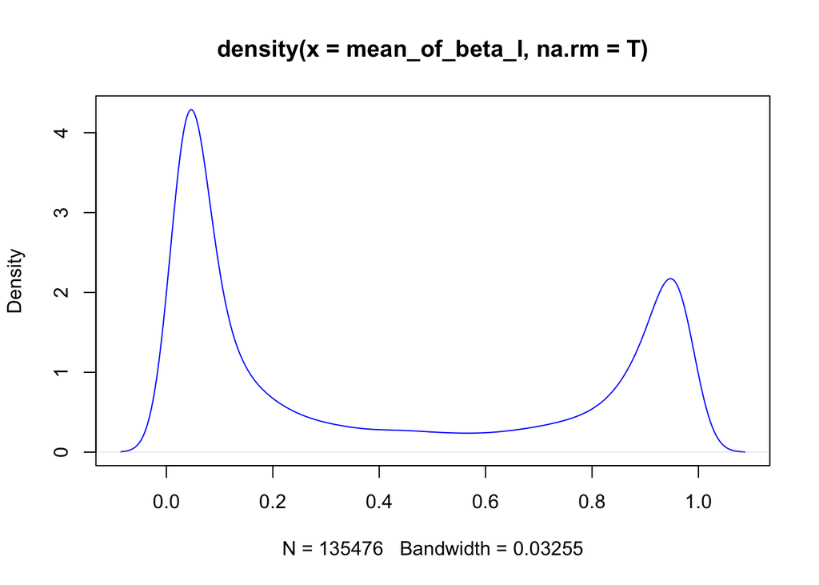

```r
plot(d_mean_of_beta_I,col="blue")
```

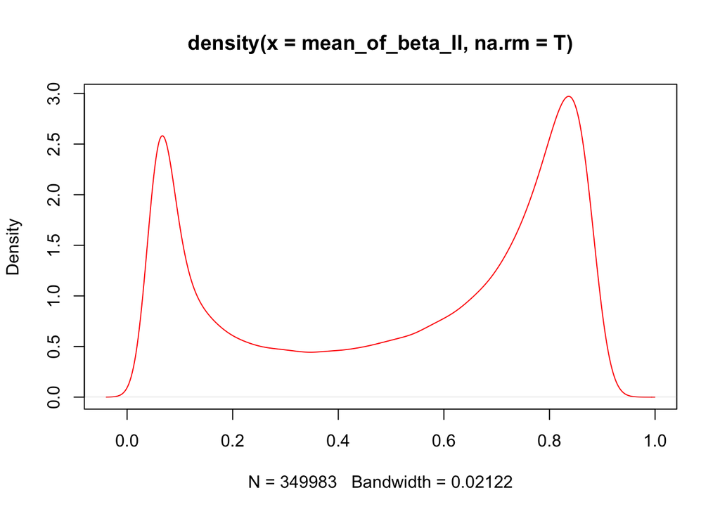

```r
plot(d_mean_of_beta_II,col="red")
```

But in this case it is more meaningful to overlay the two density distributions. To this aim, we first open a plot using the plot() function, and then we add a new line, coloured with a different color, using the lines() function

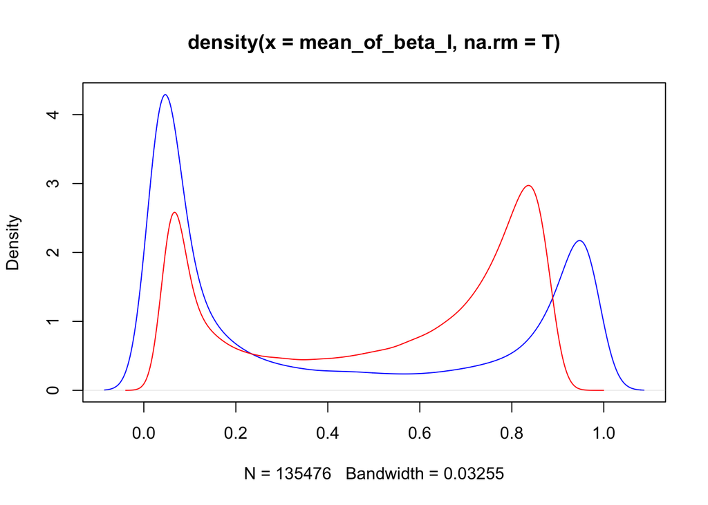

```r
plot(d_mean_of_beta_I,col="blue")
lines(d_mean_of_beta_II,col="red")
```

Note that the density distribution of beta values drom Infinium type II probes is shifted towards the centre. Moreover,type I probes have higher density at low methylation levels.

# CHUNK 4: Normalization

We will apply the preprocessQuantile function. To evaluate the effect of the normalization, we will compare raw and normalized data according to 3 types of plots:

- densities of mean beta values for type I and type II probes
- densities of standard deviation of beta values for type I and type II probes
- boxplots of beta values

For Raw data, we already have the matrix of beta valeues, the d_mean_of_beta_I and d_mean_of_beta_II objects; we need to calculate the densities of the standard deviations, which can be calculated using the function sd():

```r
sd_of_beta_I <- apply(beta_I,1,sd,na.rm=T)
sd_of_beta_II <- apply(beta_II,1,sd,na.rm=T)
d_sd_of_beta_I <- density(sd_of_beta_I,)
d_sd_of_beta_II <- density(sd_of_beta_II)
```

Now we can perform the normalization using the preprocessQuantile function.

```r
?preprocessQuantile
```

According to the help page, the input can be an RGset or MehylSet object. Let’s load the RGset object:

```r
load("~/Dropbox/DRD_2026/3/RGset.RData")
RGset
```

```
## class: RGChannelSet
## dim: 622399 8
## metadata(0):
## assays(2): Green Red
## rownames(622399): 10600313 10600322 ... 74810490 74810492
## rowData names(0):
## colnames(8): 9344737127_R01C02 9344737127_R03C02 ... 9376538140_R01C01
##   9376538140_R04C01
## colData names(9): Sample_ID Sample_Well ... Basename filenames
## Annotation
##   array: IlluminaHumanMethylation450k
##   annotation: ilmn12.hg19
```

```r
preprocessQuantile_results <- preprocessQuantile(RGset)
```

```
## [preprocessQuantile] Mapping to genome.
```

```
## [preprocessQuantile] Fixing outliers.
```

```
## [preprocessQuantile] Quantile normalizing.
```

You can have the following error: “there is no package called ’IlluminaHumanMethylation450kanno.ilmn12.hg19”; in this case you have to install the missing package (it will take a bit):

if (!requireNamespace(“BiocManager”, quietly = TRUE))

```
install.packages("BiocManager")
```

BiocManager::install(“IlluminaHumanMethylation450kanno.ilmn12.hg19”)

```r
preprocessQuantile_results <- preprocessQuantile(RGset)
```

```
## [preprocessQuantile] Mapping to genome.
```

```
## [preprocessQuantile] Fixing outliers.
```

```
## [preprocessQuantile] Quantile normalizing.
```

```r
str(preprocessQuantile_results)
```

```
## Formal class 'GenomicRatioSet' [package "minfi"] with 8 slots
##   ..@ preprocessMethod: Named chr [1:4] "preprocessQuantile" "Raw (no normalization or bg correction)" "1.56.0" "0.4.0"
##   .. ..- attr(*, "names")= chr [1:4] "mu.norm" "rg.norm" "minfi" "manifest"
##   ..@ annotation      : Named chr [1:2] "IlluminaHumanMethylation450k" "ilmn12.hg19"
##   .. ..- attr(*, "names")= chr [1:2] "array" "annotation"
##   ..@ rowRanges       :Formal class 'GRanges' [package "GenomicRanges"] with 7 slots
##   .. .. ..@ seqnames       :Formal class 'Rle' [package "S4Vectors"] with 4 slots
##   .. .. .. .. ..@ values         : Factor w/ 24 levels "chr1","chr2",..: 1 2 3 4 5 6 7 8 9 10 ...
##   .. .. .. .. ..@ lengths        : int [1:24] 46857 34810 25159 20464 24327 36611 30017 20950 9861 24388 ...
##   .. .. .. .. ..@ elementMetadata: NULL
##   .. .. .. .. ..@ metadata       : list()
##   .. .. ..@ ranges         :Formal class 'IRanges' [package "IRanges"] with 6 slots
##   .. .. .. .. ..@ start          : int [1:485512] 15865 18827 29407 29425 29435 68849 69591 91550 135252 449076 ...
##   .. .. .. .. ..@ width          : int [1:485512] 1 1 1 1 1 1 1 1 1 1 ...
##   .. .. .. .. ..@ NAMES          : chr [1:485512] "cg13869341" "cg14008030" "cg12045430" "cg20826792" ...
##   .. .. .. .. ..@ elementType    : chr "ANY"
##   .. .. .. .. ..@ elementMetadata: NULL
##   .. .. .. .. ..@ metadata       : list()
##   .. .. ..@ strand         :Formal class 'Rle' [package "S4Vectors"] with 4 slots
##   .. .. .. .. ..@ values         : Factor w/ 3 levels "+","-","*": 3
##   .. .. .. .. ..@ lengths        : int 485512
##   .. .. .. .. ..@ elementMetadata: NULL
##   .. .. .. .. ..@ metadata       : list()
##   .. .. ..@ seqinfo        :Formal class 'Seqinfo' [package "Seqinfo"] with 4 slots
##   .. .. .. .. ..@ seqnames   : chr [1:24] "chr1" "chr2" "chr3" "chr4" ...
##   .. .. .. .. ..@ seqlengths : int [1:24] NA NA NA NA NA NA NA NA NA NA ...
##   .. .. .. .. ..@ is_circular: logi [1:24] NA NA NA NA NA NA ...
##   .. .. .. .. ..@ genome     : chr [1:24] "hg19" "hg19" "hg19" "hg19" ...
##   .. .. ..@ elementMetadata:Formal class 'DFrame' [package "S4Vectors"] with 6 slots
##   .. .. .. .. ..@ rownames       : NULL
##   .. .. .. .. ..@ nrows          : int 485512
##   .. .. .. .. ..@ elementType    : chr "ANY"
##   .. .. .. .. ..@ elementMetadata: NULL
##   .. .. .. .. ..@ metadata       : list()
##   .. .. .. .. ..@ listData       : Named list()
##   .. .. ..@ elementType    : chr "ANY"
##   .. .. ..@ metadata       : list()
##   ..@ colData         :Formal class 'DFrame' [package "S4Vectors"] with 6 slots
##   .. .. ..@ rownames       : chr [1:8] "9344737127_R01C02" "9344737127_R03C02" "9344737127_R06C01" "9344737127_R02C02" ...
##   .. .. ..@ nrows          : int 8
```

[output cut: 27 more lines]

```
##   .. .. .. .. .. .. ..- attr(*, "dimnames")=List of 2
##   .. .. .. .. .. .. .. ..$ : chr [1:485512] "cg13869341" "cg14008030" "cg12045430" "cg20826792" ...
##   .. .. .. .. .. .. .. ..$ : chr [1:8] "9344737127_R01C02" "9344737127_R03C02" "9344737127_R06C01" "9344737127_R02C02" ...
##   .. .. .. .. ..@ elementType    : chr "ANY"
##   .. .. .. .. ..@ elementMetadata: NULL
##   .. .. .. .. ..@ metadata       : list()
##   ..@ NAMES           : NULL
##   ..@ elementMetadata :Formal class 'DFrame' [package "S4Vectors"] with 6 slots
##   .. .. ..@ rownames       : NULL
##   .. .. ..@ nrows          : int 485512
##   .. .. ..@ elementType    : chr "ANY"
##   .. .. ..@ elementMetadata: NULL
##   .. .. ..@ metadata       : list()
##   .. .. ..@ listData       : Named list()
##   ..@ metadata        : list()
```

```r
class(preprocessQuantile_results)
```

```
## [1] "GenomicRatioSet"
## attr(,"package")
## [1] "minfi"
```

```r
preprocessQuantile_results
```

```
## class: GenomicRatioSet
## dim: 485512 8
## metadata(0):
## assays(2): M CN
## rownames(485512): cg13869341 cg14008030 ... cg08265308 cg14273923
## rowData names(0):
## colnames(8): 9344737127_R01C02 9344737127_R03C02 ... 9376538140_R01C01
##   9376538140_R04C01
## colData names(12): Sample_ID Sample_Well ... yMed predictedSex
## Annotation
##   array: IlluminaHumanMethylation450k
##   annotation: ilmn12.hg19
## Preprocessing
##   Method: Raw (no normalization or bg correction)
##   minfi version: 1.56.0
##   Manifest version: 0.4.0
```

```r
?GenomicRatioSet
```

You see that getBeta is among the accessor functions of a GenomicRatioSet class object

```r
beta_preprocessQuantile <- getBeta(preprocessQuantile_results)
head(beta_preprocessQuantile)
```

```
##            9344737127_R01C02 9344737127_R03C02 9344737127_R06C01
## cg13869341        0.73914779        0.76950459         0.6995062
## cg14008030        0.69185593        0.64592974         0.6885158
## cg12045430        0.13474718        0.11699326         0.1004484
## cg20826792        0.17078769        0.28879485         0.2947075
## cg00381604        0.05846309        0.09592991         0.1045477
## cg20253340        0.42958351        0.51681548         0.4396129
##            9344737127_R02C02 9376538140_R02C01 9376538140_R05C01
## cg13869341         0.7184184        0.78299289        0.77009158
## cg14008030         0.6031361        0.63207688        0.56279678
## cg12045430         0.1218535        0.14349114        0.12472814
## cg20826792         0.2819566        0.22464011        0.20651747
## cg00381604         0.1000693        0.09964109        0.08688974
## cg20253340         0.4760213        0.46439970        0.37458736
##            9376538140_R01C01 9376538140_R04C01
## cg13869341         0.7751171         0.8177119
## cg14008030         0.6861439         0.6460894
## cg12045430         0.4254814         0.1188433
## cg20826792         0.3439327         0.2847663
## cg00381604         0.3128018         0.1086204
## cg20253340         0.4502786         0.6004477
```

Now, as we have done before for raw data, we divide the beta_preprocessQuantile matrix according to type I and type II probes, calculate the mean and the standartd deviation for each probe across the 8 samples and calculate the density distributions

```r
beta_preprocessQuantile_I <- beta_preprocessQuantile[rownames(beta_preprocessQuantile) %in% dfI$IlmnID,]
beta_preprocessQuantile_II <- beta_preprocessQuantile[rownames(beta_preprocessQuantile) %in% dfII$IlmnID,]
mean_of_beta_preprocessQuantile_I <- apply(beta_preprocessQuantile_I,1,mean)
mean_of_beta_preprocessQuantile_II <- apply(beta_preprocessQuantile_II,1,mean)
d_mean_of_beta_preprocessQuantile_I <- density(mean_of_beta_preprocessQuantile_I,na.rm=T)
d_mean_of_beta_preprocessQuantile_II <- density(mean_of_beta_preprocessQuantile_II,na.rm=T)
sd_of_beta_preprocessQuantile_I <- apply(beta_preprocessQuantile_I,1,sd)
sd_of_beta_preprocessQuantile_II <- apply(beta_preprocessQuantile_II,1,sd)
d_sd_of_beta_preprocessQuantile_I <- density(sd_of_beta_preprocessQuantile_I,na.rm=T)
d_sd_of_beta_preprocessQuantile_II <- density(sd_of_beta_preprocessQuantile_II,na.rm=T)
```

And here it is our beatiful plot!

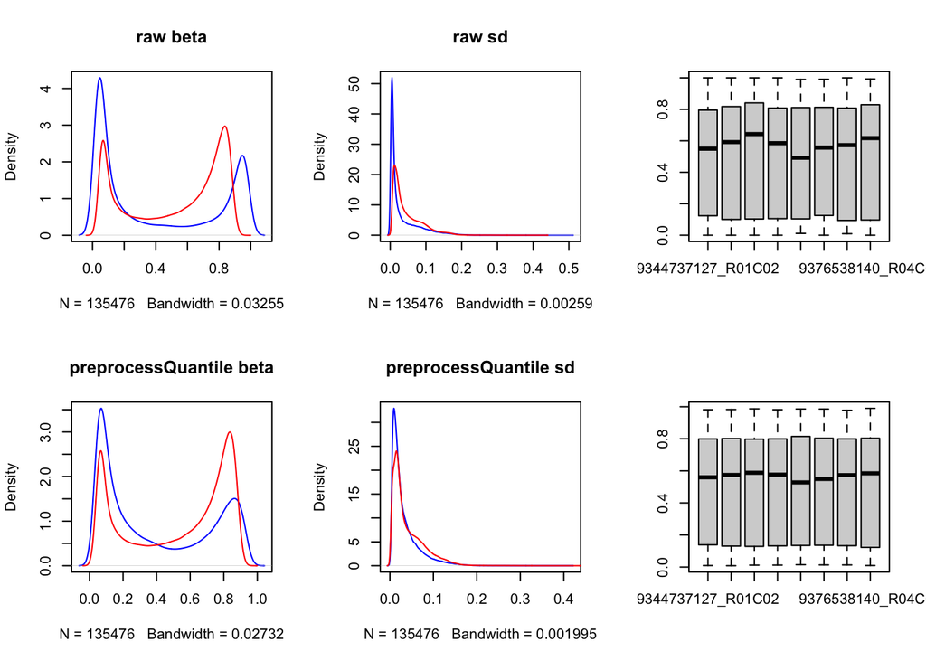

```r
par(mfrow=c(2,3))
plot(d_mean_of_beta_I,col="blue",main="raw beta")
lines(d_mean_of_beta_II,col="red")
plot(d_sd_of_beta_I,col="blue",main="raw sd")
lines(d_sd_of_beta_II,col="red")
boxplot(beta)
plot(d_mean_of_beta_preprocessQuantile_I,col="blue",main="preprocessQuantile beta")
lines(d_mean_of_beta_preprocessQuantile_II,col="red")
plot(d_sd_of_beta_preprocessQuantile_I,col="blue",main="preprocessQuantile sd")
lines(d_sd_of_beta_preprocessQuantile_II,col="red")
boxplot(beta_preprocessQuantile)
```

Note that it is easier to compare the plots if we have the same scales on x and y axes; to this aim, we can specify the xlim and ylim arguments:

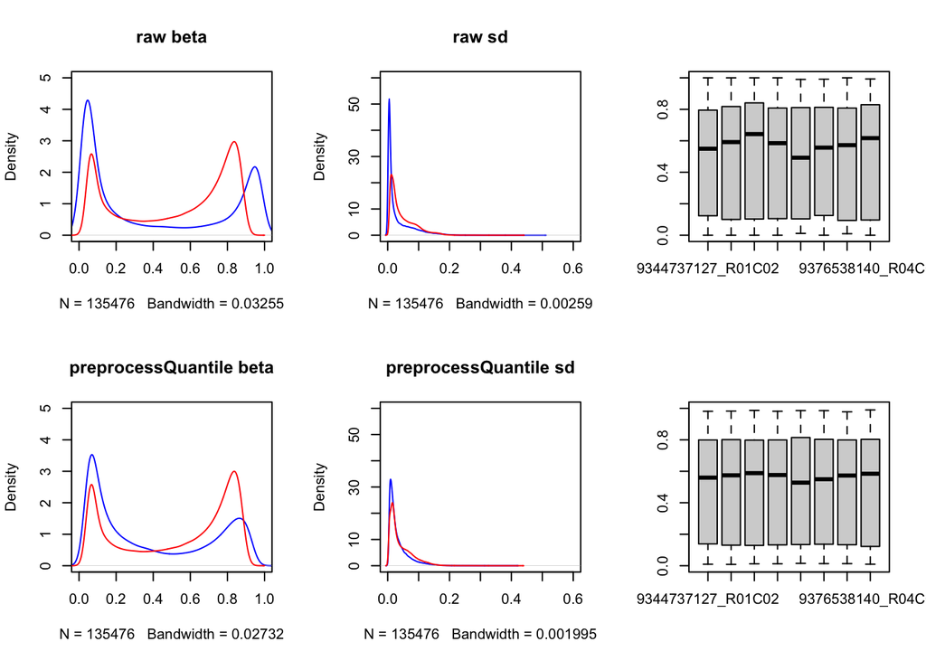

```r
par(mfrow=c(2,3))
plot(d_mean_of_beta_I,col="blue",main="raw beta",xlim=c(0,1),ylim=c(0,5))
lines(d_mean_of_beta_II,col="red")
plot(d_sd_of_beta_I,col="blue",main="raw sd",xlim=c(0,0.6),ylim=c(0,60))
lines(d_sd_of_beta_II,col="red")
boxplot(beta,ylim=c(0,1))
plot(d_mean_of_beta_preprocessQuantile_I,col="blue",main="preprocessQuantile beta",xlim=c(0,1),ylim=c(0,5))
lines(d_mean_of_beta_preprocessQuantile_II,col="red")
plot(d_sd_of_beta_preprocessQuantile_I,col="blue",main="preprocessQuantile sd",xlim=c(0,0.6),ylim=c(0,60))
lines(d_sd_of_beta_preprocessQuantile_II,col="red")
boxplot(beta_preprocessQuantile,ylim=c(0,1))
```

We can save this plot in a pdf

```r
pdf("Plot_comparison_raw_preprocessQuantile.pdf",height=7,width=15)
par(mfrow=c(2,3))
plot(d_mean_of_beta_I,col="blue",main="raw beta",xlim=c(0,1),ylim=c(0,5))
lines(d_mean_of_beta_II,col="red")
plot(d_sd_of_beta_I,col="blue",main="raw sd",xlim=c(0,0.6),ylim=c(0,60))
lines(d_sd_of_beta_II,col="red")
boxplot(beta,ylim=c(0,1))
plot(d_mean_of_beta_preprocessQuantile_I,col="blue",main="preprocessQuantile beta",xlim=c(0,1),ylim=c(0,5))
lines(d_mean_of_beta_preprocessQuantile_II,col="red")
plot(d_sd_of_beta_preprocessQuantile_I,col="blue",main="preprocessQuantile sd",xlim=c(0,0.6),ylim=c(0,60))
lines(d_sd_of_beta_preprocessQuantile_II,col="red")
boxplot(beta_preprocessQuantile,ylim=c(0,1))
dev.off()
```

Try by yourself preprocessFunnorm, preprocessNoob and preprocessSWAN